# Aortic valve analysis

Steve Simon

May 25, 2017

```r
source("prelims.R", echo=FALSE)
av1 <- read.csv("av1_2017_05_29.csv", as.is=TRUE)
av3 <- read.csv("av3_2017_05_29.csv", as.is=TRUE)
av4 <- read.csv("av4_2017_05_29.csv", as.is=TRUE)

mv1 <- read.csv("mv1_2017_05_29.csv", as.is=TRUE)
mv4 <- read.csv("mv4_2017_05_29.csv", as.is=TRUE)


names(av1) %<>% clean_up_names
names(av3) %<>% clean_up_names
names(av4) %<>% clean_up_names

names(mv1) %<>% clean_up_names
names(mv4) %<>% clean_up_names

av1 <- remove_empty_space(av1)
```

```
##
## *** av1
## Empty rows: none
## Empty columns: unos_re_tx_date, av_under18, x, x_1, x_2, x_3, x_4, x_5, x_6, x_7, x_8, x_9, x_10, x_11, x_12, x_13, x_14, x_15, x_16, x_17, x_18, x_19, x_20, x_21, x_22, x_23, x_24, x_25, x_26, x_27, x_28, x_29, x_30, x_31, x_32, x_33, x_34, x_35, x_36, x_37, x_38, x_39, x_40, x_41, x_42, x_43, x…
## av1 has 1198 rows and 135 columns reduced to 1198 rows and 65 columns
```

```r
av3 <- remove_empty_space(av3)
```

```
##
## *** av3
## Empty rows: 297, 298, 299, 300, 301, 302, 303, 304, 305, 306, 307, 308, 309, 310, 311, 312, 313, 314, 315, 316, 317
## Empty columns: ea_10, ea_desc_10, ea_11, ea_desc_11, ea_12, ea_desc_12, ea_13, ea_desc_13, ea_14, ea_desc_14, ea_15, ea_desc_15, ea_16, ea_desc_16, ea_17, ea_desc_17, ea_18, ea_desc_18, ea_19, ea_desc_19, ea_20, ea_desc_20, ra_10, ra_desc_10, ra_11, ra_desc_11, ra_12, ra_desc_12, ra_13, ra_desc_1…
## av3 has 317 rows and 86 columns reduced to 296 rows and 42 columns
```

```r
av4 <- remove_empty_space(av4)
```

```
##
## *** av4
## Empty rows: none
## Empty columns: x, x_1, x_2, x_3, x_4
## av4 has 26 rows and 12 columns reduced to 26 rows and 7 columns
```

```r
mv1 <- remove_empty_space(mv1)
```

```
##
## *** mv1
## Empty rows: none
## Empty columns: av_under18, x, x_1, x_2, x_3, x_4, x_5, x_6, x_7, x_8, x_9, x_10, x_11, x_12, x_13, x_14
## mv1 has 644 rows and 93 columns reduced to 644 rows and 77 columns
```

```r
mv4 <- remove_empty_space(mv4)
```

```
##
## *** mv4
## Empty rows: none
## Empty columns: ea_14, ea_desc_14, ea_15, ea_desc_15, ea_16, ea_desc_16, ea_17, ea_desc_17, ea_18, ea_desc_18, ea_19, ea_desc_19, ea_20, ea_desc_20, ra_11, ra_desc_11, ra_12, ra_desc_12, ra_13, ra_desc_13, ra_14, ra_desc_14, ra_15, ra_desc_15, ra_16, ra_desc_16, ra_17, ra_desc_17, ra_18, ra_desc_1…
## mv4 has 251 rows and 85 columns reduced to 251 rows and 51 columns
```

```r
av1 <- check_ids(av1)
av3 <- check_ids(av3)
```

```
##
##
## Missing id in av3
##     id date_of_death state_of_death cardiac_non_cardiac_y_n cause_of_death
## 296 NA
##     cause_of_death_desc ea_1 ea_desc_1 ea_2
## 296
##                             ea_desc_2 ea_3
## 296 complex congenital heart disease
##                                             ea_desc_3 ea_4 ea_desc_4 ea_5
## 296 shock liver with extensive centrilobular necrosis
##     ea_desc_5 ea_6 ea_desc_6 ea_7 ea_desc_7 ea_8 ea_desc_8 ea_9 ea_desc_9
## 296
##     ra_1 ra_desc_1 ra_2 ra_desc_2 ra_3 ra_desc_3 ra_4 ra_desc_4 ra_5
## 296
##     ra_desc_5 ra_6 ra_desc_6 ra_7 ra_desc_7 ra_8 ra_desc_8 ra_9 ra_desc_9
## 296
```

```r
av4 <- check_ids(av4)

mv1 <- check_ids(mv1)
mv4 <- check_ids(mv4)

{
  cat("\n\n\n\n**** Note new codes: ")
  cat("998 (was 888), ")
  cat("997 (was blank), ")
  cat("996 (was missing), ")
  cat("995 (unfixable)")
  cat("\n\n")
}
```

```
##
##
##
##
## **** Note new codes: 998 (was 888), 997 (was blank), 996 (was missing), 995 (unfixable)
```

```r
av1 <- loop_through_dates(av1)
```

```
##
##
##
##
## **** av1 birthdate
## No special cases!
##
##
##
##
## **** Revised av1 birthdate
## No special cases!
##
##
##
##
##
## **** av1 first_admit_date
## No special cases!
##
##
##
##
## **** Revised av1 first_admit_date
## No special cases!
##
##
##
##
##
## **** av1 date_of_valve_replacement
## Special cases.
##    888    999 999.00    Sum
##      1     31      1     33
##
## Bad year
## 00/00/91 07/00/95  1/00/02
##        1        1        1
## 0/00/1982 changed to 07/01/1982
## 00/00/1976 changed to 07/01/1976
```

[output cut: 227 more lines]

```
##
##
##
##
## **** av1 ndi_date_of_death
## Special cases.
##     Sum
## 990 990
##  changed to 997
##
##
## **** Revised av1 ndi_date_of_death
## Special cases.
## 997 Sum
## 990 990
```

```r
av3 <- loop_through_dates(av3)
```

```
##
##
##
##
## **** av3 date_of_death
## No special cases!
##
##
##
##
## **** Revised av3 date_of_death
## No special cases!
```

```r
av4 <- loop_through_dates(av4)
```

```
##
##
##
##
## **** av4 date_of_death
## No special cases!
##
##
##
##
## **** Revised av4 date_of_death
## No special cases!
```

```r
mv1 <- loop_through_dates(mv1)
```

```
##
##
##
##
## **** mv1 birthdate
## No special cases!
##
##
##
##
## **** Revised mv1 birthdate
## No special cases!
##
##
##
##
##
## **** mv1 first_admit_date
## No special cases!
##
##
##
##
## **** Revised mv1 first_admit_date
## No special cases!
##
##
##
##
##
## **** mv1 date_of_valve_replacement
## Special cases.
## 999 Sum
##  16  16
## 00/00/1974 changed to 07/01/1974
## 00/00/1977 changed to 07/01/1977
## 00/00/1979 changed to 07/01/1979
## 00/00/1980 changed to 07/01/1980
## 00/00/1981 changed to 07/01/1981
## 00/00/1985 changed to 07/01/1985
```

[output cut: 224 more lines]

```
##
##
##
##
## **** mv1 ndi_date_of_death
## Special cases.
##     Sum
## 446 446
##  changed to 997
##
##
## **** Revised mv1 ndi_date_of_death
## Special cases.
## 997 Sum
## 446 446
```

```r
mv4 <- loop_through_dates(mv4)
```

```
##
##
##
##
## **** mv4 date_of_death
## No special cases!
##
##
##
##
## **** Revised mv4 date_of_death
## No special cases!
```

```r
print(dim(av1)[1])
```

```
## [1] 1198
```

```r
print(dim(av3)[1])
```

```
## [1] 295
```

```r
print(dim(av4)[1])
```

```
## [1] 26
```

```r
print(length(intersect(av1$id, av3$id)))
```

```
## [1] 208
```

```r
print(length(intersect(av1$id, av4$id)))
```

```
## [1] 24
```

```r
print(length(intersect(av3$id, av4$id)))
```

```
## [1] 0
```

```r
print(setdiff(av3$id, av1$id))
```

```
##  [1] 22006190000 22107130000 22206220000 22906030000 22907040000
##  [6] 23306080000 23406110000 23511080000 23511130000 24208200000
## [11] 24301040000 24309020000 24512240000 24707190000 24805020000
## [16] 25009120000 25011060000 25211180000 25304270000 25508220001
## [21] 25603280000 25605110000 25607170000 25712240000 26105040000
## [26] 26107210000 26109270000 26201060000 26206150001 26206200000
## [31] 26208080000 26208190000 26311160000 26406110002 26407200000
## [36] 26504020001 26505010000 26509070000 26601060002 26602080000
## [41] 26603290000 26607160001 26703130000 26708240000 26801030001
## [46] 26801260001 26806240002 26902010004 26907220003 27002010002
## [51] 27002240003 27007290004 27011250000 27109140001 27203080002
## [56] 27210300002 27211250001 27312120003 27401230002 27406270003
## [61] 27409230006 27411010002 27508010000 27511300003 27512280000
## [66] 27603200003 27610140001 27703100003 27710250005 27802210001
## [71] 27806200000 27809260006 27810020001 27812180002 27902090004
## [76] 27904020004 27904210007 27906060000 27907050003 27909130008
## [81] 28004060001 28006020006 28007230005 28011060006 28107110003
## [86] 28110180003 28411070006
```

```r
print(dim(mv1)[1])
```

```
## [1] 644
```

```r
print(dim(mv4)[1])
```

```
## [1] 251
```

```r
print(length(intersect(mv1$id, mv4$id)))
```

```
## [1] 198
```

```r
print(setdiff(mv4$id, mv1$id))
```

```
##  [1] 20911300000 22006190000 22208140000 22208220000 22308240000
##  [6] 22712030000 23107260000 23402200000 23406280000 23511130000
## [11] 23902130000 24201310000 24207230001 24302270000 24708300000
## [16] 24801130000 24908220000 24912120000 25102210000 25401090000
## [21] 25408310001 25503200000 25702010000 26007310000 26110310000
## [26] 26203290001 26205060000 26208190000 26209070000 26305140000
## [31] 26306210000 26310170000 26405210000 26505110000 26511140000
## [36] 26602080000 26603250000 26702160000 26705250002 26903150001
## [41] 27001100003 27003010000 27003210002 27105130002 27302220000
## [46] 27305090002 27305150003 27505070000 27705260004 27903220003
## [51] 28004060001 28103160009 28209260001
```

AORTIC

1. Arithmetic data for columns where possible – mean, median, SD, range
2. What is the long-term survival of children with AVR?
3. Head to head comparison of Ross versus Bio prosthesis versus Mechanical prosthesis looking at survival within the 3 groups ==> ross_bio_mech and relation to following
- Age at 1st AVR ==> date_of_valve_replacement MINUS birthdate
- Weight at 1st AVR ==> weight_at_surgery_kg
- Valve type at 1st AVR ==> mechanical_valve_used_y_n AND valve_make
- Valve size at 1st AVR ==> valve_size_mm
- Underlying disease ==> underlying_disease_ex_cavc_etc
- Underlying hemodynamic mechanism – AR versus AS versus both ==> underlying_lesion_regurgitation_or_stenosis
- Perfusion time ==> cpb_time_minutes
- Concomitant prosthetic MVR ==> additional_valve_replaced_mitral_pulm_tri
- Initial Hospital length of stay ==> discharge_date MINUS date_of_valve_replacement
- Era effect - < 1990 versus 1990s and up to 2003 ==> date_of_valve_replacement
- Geography – State ==> state
- Institution
4. Causes of death – Big piles only
5. Early deaths (PCCC) versus late deaths (NDI) – compare profiles
6. Interactions
7. Confounders – collinearity
8. Kaplan Meir – Ross versus Bio versus Mechanical AVR
9. Competing risk – will think thru this some more
10. Redo stuff – we may not have time for this before abstract deadline

```r
m_codes <- as.character(995:999)

calculate_days <- function(df, v) {
  dfname <- deparse(substitute(df))
  vname <- deparse(substitute(v))
  t0 <- mdy("1/1/1950") # our overall reference point
  missing_codes <- df[, vname] %in% m_codes
  cat("\nThere are ")
  cat(dim(df)[1]-sum(missing_codes))
  cat(" valid values out of ")
  cat(dim(df)[1])
  cat(" for ")
  cat(paste(dfname, vname, sep="$"))
  cat(".\n")
  days <- mdy(df[, vname])-t0
  if (sum(is.na(days)>sum(missing_codes))) {
    cat("\nValues for which conversion was not possible\n")
    df[is.na(days)&!missing_codes, vname] %>% table %>% print
  }
  return(days)
}

av3                                             %>%
  bind_rows(av4)                                %>%
  filter(!(date_of_death %in% m_codes))         %>%
  select(id, date_of_death)                     %>%
  right_join(av1)                               -> av5
av5[is.na(av5$date_of_death), "date_of_death"] <- 996

av5$d_birth <- calculate_days(av5, birthdate)
```

```
##
## There are 1198 valid values out of 1198 for av5$birthdate.
```

```r
av5$d_vr1   <- calculate_days(av5, date_of_valve_replacement)
```

```
##
## There are 1165 valid values out of 1198 for av5$date_of_valve_replacement.
```

```r
av5$d_vr2   <- calculate_days(av5, date_of_valve_replacement_1)
```

```
##
## There are 170 valid values out of 1198 for av5$date_of_valve_replacement_1.
```

```r
av5$d_vr3   <- calculate_days(av5, date_of_valve_replacement_2)
```

```
##
## There are 27 valid values out of 1198 for av5$date_of_valve_replacement_2.
```

```r
av5$d_dis1  <- calculate_days(av5, discharge_date)
```

```
##
## There are 1116 valid values out of 1198 for av5$discharge_date.
```

```r
av5$d_dis2  <- calculate_days(av5, discharge_date_1)
```

```
##
## There are 165 valid values out of 1198 for av5$discharge_date_1.
```

```r
av5$d_dis3  <- calculate_days(av5, discharge_date_2)
```

```
##
## There are 23 valid values out of 1198 for av5$discharge_date_2.
```

```r
av5$d_tx    <- calculate_days(av5, unos_tx_date)
```

```
##
## There are 19 valid values out of 1198 for av5$unos_tx_date.
```

```r
av5$d_death <- calculate_days(av5, date_of_death)
```

```
##
## There are 232 valid values out of 1198 for av5$date_of_death.
```

```r
av5$d_cens  <- mdy("12/30/2014") - mdy("1/1/1950")

mv4                                             %>%
  filter(!(date_of_death %in% m_codes))         %>%
  select(id, date_of_death)                     %>%
  right_join(mv1)                               -> mv5
mv5[is.na(mv5$date_of_death), "date_of_death"] <- 996

mv5$d_birth <- calculate_days(mv5, birthdate)
```

```
##
## There are 644 valid values out of 644 for mv5$birthdate.
```

```r
mv5$d_vr1   <- calculate_days(mv5, date_of_valve_replacement)
```

```
##
## There are 628 valid values out of 644 for mv5$date_of_valve_replacement.
```

```r
mv5$d_vr2   <- calculate_days(mv5, date_of_valve_replacement_1)
```

```
##
## There are 161 valid values out of 644 for mv5$date_of_valve_replacement_1.
```

```r
mv5$d_vr3   <- calculate_days(mv5, date_of_valve_replacement_2)
```

```
##
## There are 23 valid values out of 644 for mv5$date_of_valve_replacement_2.
```

```r
mv5$d_dis1  <- calculate_days(mv5, discharge_date)
```

```
##
## There are 569 valid values out of 644 for mv5$discharge_date.
```

```r
mv5$d_dis2  <- calculate_days(mv5, discharge_date_1)
```

```
##
## There are 156 valid values out of 644 for mv5$discharge_date_1.
```

```r
mv5$d_dis3  <- calculate_days(mv5, discharge_date_2)
```

```
##
## There are 22 valid values out of 644 for mv5$discharge_date_2.
```

```r
mv5$d_tx    <- calculate_days(mv5, unos_tx_date)
```

```
##
## There are 24 valid values out of 644 for mv5$unos_tx_date.
```

```r
mv5$d_death <- calculate_days(mv5, date_of_death)
```

```
##
## There are 198 valid values out of 644 for mv5$date_of_death.
```

```r
mv5$d_cens  <- mdy("12/30/2014") - mdy("1/1/1950")
```

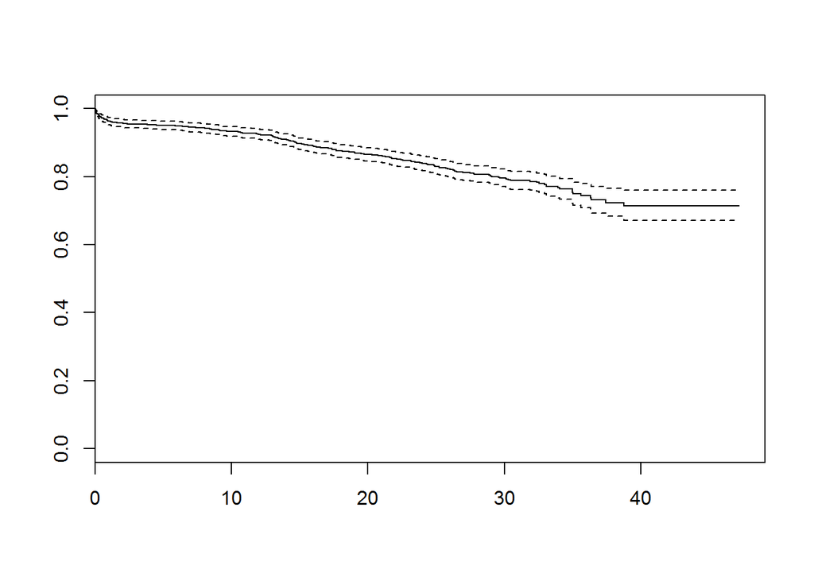

```r
t1 <- av5$d_death-av5$d_birth
t2 <- av5$d_cens -av5$d_birth
t <- ifelse(is.finite(t1), t1, t2)
cens <- as.numeric(is.finite(t1))
av_mortality <- Surv(time=round(t/365.25, 4), event=cens)
plot(survfit(av_mortality~1))
```

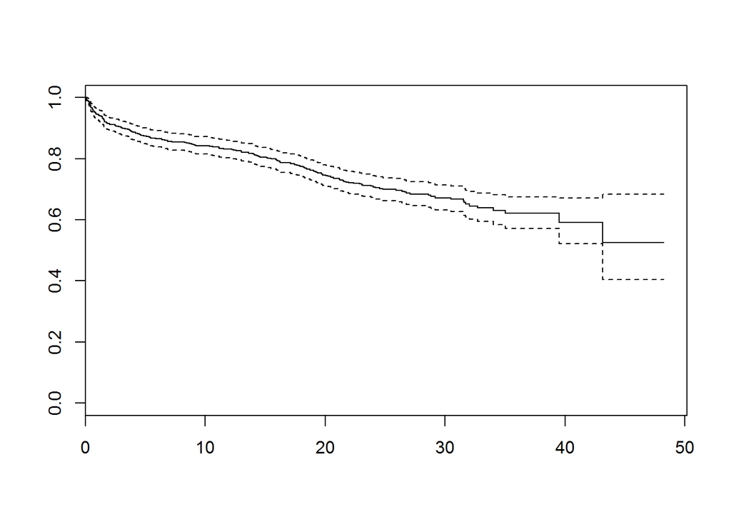

```r
t1 <- mv5$d_death-mv5$d_birth
t2 <- mv5$d_cens -mv5$d_birth
t <- ifelse(is.finite(t1), t1, t2)
cens <- as.numeric(is.finite(t1))
mv_mortality <- Surv(time=round(t/365.25, 4), event=cens)
plot(survfit(mv_mortality~1))
```